# Doing statistics in R

Session Seven

Akos Mate

2019 July

> Main packages used: `base R`, `broom`, `ggplot2`  
> Main functions covered: `t.test`, `cor`, `lm`, `str`, `broom::tidy`, `broom::augment`, `broom::glance`

# 1 Statistical analysis and modelling in R

Packages we will need.

```r
packages_s7 <- c("ggfortify", "effects", "GGally", "broom")

install.packages(packages_s7)
```

```r
# data import and cleaning
library(readr)
library(dplyr)
library(haven)

# statistical modelling
# library(survey) # package for analyzing survey data
# library(plm) # package for panel regressions
library(broom) # extracting model informations


# practice data
library(gapminder)

# data visualization
library(ggplot2)
library(ggfortify)
library(effects)
library(GGally)
```

## 1.1 Student’s t-test

The t-test is a simple, yet powerful statistical technique to check whether two sample means differ from each other statistically significantly. For experimental setups you can examine if your treatment caused a statistically significant effect compared to your control group for example. The validity of the test is based on the assumptions that our sample is randomly selected from the population and people are randomly distributed between the treatment and control groups as well.

Let’s look at the survey data of the European Social Survey. The data file is familiar from before as we used it for some data visualization excercises. It contains a select few variables from the Hungarian survey.

```r
ess_data <- read_csv("data/ESS_Hun_7.csv")
glimpse(ess_data)
```

```
#> Observations: 1,698
#> Variables: 18
#> $ X1       <dbl> 1, 2, 3, 4, 5, 6, 7, 8, 9, 10, 11, 12, 13, 14, 15, 16...
#> $ cntry    <chr> "HU", "HU", "HU", "HU", "HU", "HU", "HU", "HU", "HU",...
#> $ cname    <chr> "ESS1-7e01", "ESS1-7e01", "ESS1-7e01", "ESS1-7e01", "...
#> $ cedition <dbl> 1, 1, 1, 1, 1, 1, 1, 1, 1, 1, 1, 1, 1, 1, 1, 1, 1, 1,...
#> $ cproddat <chr> "08.12.2016", "08.12.2016", "08.12.2016", "08.12.2016...
#> $ cseqno   <dbl> 181201, 181202, 181203, 181204, 181205, 181206, 18120...
#> $ name     <chr> "ESS7e02_1", "ESS7e02_1", "ESS7e02_1", "ESS7e02_1", "...
#> $ essround <dbl> 7, 7, 7, 7, 7, 7, 7, 7, 7, 7, 7, 7, 7, 7, 7, 7, 7, 7,...
#> $ edition  <dbl> 2.1, 2.1, 2.1, 2.1, 2.1, 2.1, 2.1, 2.1, 2.1, 2.1, 2.1...
#> $ idno     <dbl> 1001, 1004, 1005, 1006, 1008, 1010, 1011, 1012, 1015,...
#> $ dweight  <dbl> 1, 1, 1, 1, 1, 1, 1, 1, 1, 1, 1, 1, 1, 1, 1, 1, 1, 1,...
#> $ pspwght  <dbl> 1.1876964, 0.6984509, 1.0995831, 1.0972840, 0.9570787...
#> $ pweight  <dbl> 0.4977355, 0.4977355, 0.4977355, 0.4977355, 0.4977355...
#> $ tvpol    <dbl> 1, 1, 1, 2, 1, 2, 1, 0, 2, 1, 1, 1, 66, 1, 2, 66, 1, ...
#> $ polintr  <dbl> 4, 4, 4, 1, 4, 4, 3, 3, 4, 2, 3, 4, 4, 3, 4, 4, 4, 3,...
#> $ trstlgl  <dbl> 6, 0, 0, 10, 0, 88, 0, 7, 5, 2, 4, 6, 5, 0, 3, 3, 2, ...
#> $ mmbprty  <lgl> NA, NA, NA, NA, NA, NA, NA, NA, NA, NA, NA, NA, NA, N...
#> $ gndr     <dbl> 2, 1, 1, 2, 2, 1, 2, 2, 2, 1, 1, 2, 2, 2, 1, 1, 2, 1,...
```

Let’s further trim the dataset, so we only have what we need right now. We will also eliminate the “No Response”, “Don’t Know” codes, by filtering these values out. Note: in a real analysis these still carry information, but for us they would pose needless complications. We also create a factor variable from the gender one, by specifying the levels and corresponding labels.

```r
ess_sample <- ess_data %>%
    select(cntry, tvpol:gndr) %>%
    filter(tvpol < 66, polintr < 7, trstlgl < 11, gndr < 3) %>%
    mutate(gndr = factor(gndr, levels = c(1,2), labels = c("male", "female")))

glimpse(ess_sample)
```

```
#> Observations: 1,596
#> Variables: 6
#> $ cntry   <chr> "HU", "HU", "HU", "HU", "HU", "HU", "HU", "HU", "HU", ...
#> $ tvpol   <dbl> 1, 1, 1, 2, 1, 1, 0, 2, 1, 1, 1, 1, 2, 1, 2, 2, 1, 2, ...
#> $ polintr <dbl> 4, 4, 4, 1, 4, 3, 3, 4, 2, 3, 4, 3, 4, 4, 3, 2, 4, 4, ...
#> $ trstlgl <dbl> 6, 0, 0, 10, 0, 0, 7, 5, 2, 4, 6, 0, 3, 2, 5, 10, 5, 5...
#> $ mmbprty <lgl> NA, NA, NA, NA, NA, NA, NA, NA, NA, NA, NA, NA, NA, NA...
#> $ gndr    <fct> female, male, male, female, female, female, female, fe...
```

```r
tv_test <- t.test(tvpol ~ gndr, data = ess_sample)

tv_test
```

```
#>
#>  Welch Two Sample t-test
#>
#> data:  tvpol by gndr
#> t = 2.1051, df = 1441.1, p-value = 0.03545
#> alternative hypothesis: true difference in means is not equal to 0
#> 95 percent confidence interval:
#>  0.009662529 0.273769272
#> sample estimates:
#>   mean in group male mean in group female
#>             1.694118             1.552402
```

We will use the `gndr` dummy variable (takes the binary values of female or male) and check if the female and male respondents differ in their political interest in a statistically significant way. The `t.test()` function implements the independent samples t-test, where we have two distinct group and we want to know if their group means are different from each other. There are other variants of the t-test, such as the one-sample t-test, the paired samples t-test, but here we are focusing on the independent samples t-test.

In R a t-test is implemented in the `t.test()` function. As a minimum, for an independent samples t-test, you just need to provide it with two vectors of data values as the first two arguments. It also accepts input in the form of a formula, which might be more convenient in some occasions.

So let’s see if men and women differ in political interest. Let’s put the results of the test into an object called `polintr_test` and print them by just calling the name of the object.

```r
polintr_test <- t.test(polintr ~ gndr, data = ess_sample)

polintr_test
```

```
#>
#>  Welch Two Sample t-test
#>
#> data:  polintr by gndr
#> t = -4.7959, df = 1425.2, p-value = 1.789e-06
#> alternative hypothesis: true difference in means is not equal to 0
#> 95 percent confidence interval:
#>  -0.2937204 -0.1231945
#> sample estimates:
#>   mean in group male mean in group female
#>             2.898529             3.106987
```

## 1.2 ANOVA (OPTIONAL)

If we are curious about the difference between more than two sample means, we can use the Analysis of Variance test. The following is a simple one-way analysis of variance – with one response variable and one explanatory variable. There are many other versions of ANOVA, that we will not have the chance to look at here.

```r
data(airquality)

# ?airquality

glimpse(airquality)
```

```
#> Observations: 153
#> Variables: 6
#> $ Ozone   <int> 41, 36, 12, 18, NA, 28, 23, 19, 8, NA, 7, 16, 11, 14, ...
#> $ Solar.R <int> 190, 118, 149, 313, NA, NA, 299, 99, 19, 194, NA, 256,...
#> $ Wind    <dbl> 7.4, 8.0, 12.6, 11.5, 14.3, 14.9, 8.6, 13.8, 20.1, 8.6...
#> $ Temp    <int> 67, 72, 74, 62, 56, 66, 65, 59, 61, 69, 74, 69, 66, 68...
#> $ Month   <int> 5, 5, 5, 5, 5, 5, 5, 5, 5, 5, 5, 5, 5, 5, 5, 5, 5, 5, ...
#> $ Day     <int> 1, 2, 3, 4, 5, 6, 7, 8, 9, 10, 11, 12, 13, 14, 15, 16,...
```

```r
anova1 <- aov(Temp ~ Month, data=airquality)

anova1
```

```
#> Call:
#>    aov(formula = Temp ~ Month, data = airquality)
#>
#> Terms:
#>                     Month Residuals
#> Sum of Squares   2413.042 11204.840
#> Deg. of Freedom         1       151
#>
#> Residual standard error: 8.614188
#> Estimated effects may be unbalanced
```

```r
summary(anova1)
```

```
#>              Df Sum Sq Mean Sq F value   Pr(>F)
#> Month         1   2413  2413.0   32.52 6.03e-08 ***
#> Residuals   151  11205    74.2
#> ---
#> Signif. codes:  0 '***' 0.001 '**' 0.01 '*' 0.05 '.' 0.1 ' ' 1
```

The most important information to look for here is the F value and the associated p-value (Pr(>F)). If the latter is less than our threshold for statistical significance (0.05 in our case), we can conclude that there is a statistically significant difference between the means of the groups. In our case the value is well below our treshold, which means that we can reject our null hypothesis of no difference between the means.

If we would want to visualise this, we could plot the group means with the error bars. First, we summarize our data then use `ggplot`.

```r
anova_sum <- airquality %>%
    group_by(Month) %>%
    summarise(mean_temp = mean(Temp), sd = sd(Temp), se = sd/sqrt(length(Temp)))

anova_sum
```

```
#> # A tibble: 5 x 4
#>   Month mean_temp    sd    se
#>   <int>     <dbl> <dbl> <dbl>
#> 1     5      65.5  6.85 1.23
#> 2     6      79.1  6.60 1.20
#> 3     7      83.9  4.32 0.775
#> 4     8      84.0  6.59 1.18
#> 5     9      76.9  8.36 1.53
```

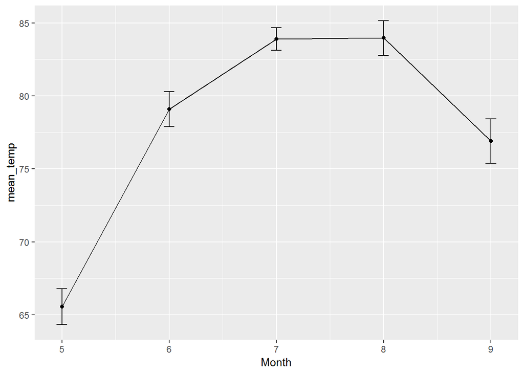

```r
ggplot(data = anova_sum,
       mapping = aes(x = Month,
                     y = mean_temp)) +
    geom_errorbar(aes(ymin = mean_temp - se, ymax = mean_temp + se), width = 0.1) +
    geom_line() +
    geom_point() +
    theme(legend.position = "none")
```

## 1.3 Correlation

Perhaps the most common approach to look into associations between variables is the correlation. There are also different types of correlation, here we will be talking about the Pearson correlation, which is what is usually thought of when people speak about correlation. It shows the association between two continuous variables and is implemented in R in the `cor()` and `cor.test()` functions. The first simply calculates the value of the correlation coefficient, the second also performs a statistical test to tell you if the correlation is statistically different from 0.

We will use the, by now, well known gapminder dataset for both the correlation and both the regression analysis examples. The only modifications we will make to the data is to create a cross-section of it, by limiting all observations to the year 2007.

```r
gapminder_cs <- gapminder %>%
    filter(year == 2007)


glimpse(gapminder_cs)
```

```
#> Observations: 142
#> Variables: 6
#> $ country   <fct> Afghanistan, Albania, Algeria, Angola, Argentina, Au...
#> $ continent <fct> Asia, Europe, Africa, Africa, Americas, Oceania, Eur...
#> $ year      <int> 2007, 2007, 2007, 2007, 2007, 2007, 2007, 2007, 2007...
#> $ lifeExp   <dbl> 43.828, 76.423, 72.301, 42.731, 75.320, 81.235, 79.8...
#> $ pop       <int> 31889923, 3600523, 33333216, 12420476, 40301927, 204...
#> $ gdpPercap <dbl> 974.5803, 5937.0295, 6223.3675, 4797.2313, 12779.379...
```

The `cor()` function is useful, because it provides the possibility to look at many variables at once. So let’s have a look at all the correlations between the variables in the dataset. The `cor()` function is picky about missing data and therefore we have to tell it to drop the cases with missing values on a variable for the calculation of a specific correlation. The `"pairwise.complete"` option tells it to use for each correlation the set of observations that complete.

In the function call, I specify that I want the correlation between the last three variables.

```r
cor(gapminder_cs[, 4:6], use = "pairwise.complete", method = "pearson")
```

```
#>              lifeExp         pop  gdpPercap
#> lifeExp   1.00000000  0.04755312  0.6786624
#> pop       0.04755312  1.00000000 -0.0556756
#> gdpPercap 0.67866240 -0.05567560  1.0000000
```

We can test with the `cor.test` function if the estimated correlations are statistically significant. Let’s check GDP per capita and population. They have a negative correlation, but we do not really know if this is significant or not. (yet)

```r
cor1 <- cor.test(gapminder_cs$pop, gapminder_cs$gdpPercap, method = "pearson")

cor1
```

```
#>
#>  Pearson's product-moment correlation
#>
#> data:  gapminder_cs$pop and gapminder_cs$gdpPercap
#> t = -0.65979, df = 140, p-value = 0.5105
#> alternative hypothesis: true correlation is not equal to 0
#> 95 percent confidence interval:
#>  -0.2183999  0.1100611
#> sample estimates:
#>        cor
#> -0.0556756
```

The p-value of the test is above our treshold of p < 0.05, thus the negative correlation between the two variable is not statistically significant.

Let’s check life expectancy and GDP per capita.

```r
cor.test(gapminder_cs$lifeExp, gapminder_cs$gdpPercap)
```

```
#>
#>  Pearson's product-moment correlation
#>
#> data:  gapminder_cs$lifeExp and gapminder_cs$gdpPercap
#> t = 10.933, df = 140, p-value < 2.2e-16
#> alternative hypothesis: true correlation is not equal to 0
#> 95 percent confidence interval:
#>  0.5786217 0.7585843
#> sample estimates:
#>       cor
#> 0.6786624
```

Is p-value < 2.2e-16 small or large? Let’s make sure that we avoid scientific notation in our output with the following option:

```r
options(scipen = 999)

cor.test(gapminder_cs$lifeExp, gapminder_cs$gdpPercap)
```

```
#>
#>  Pearson's product-moment correlation
#>
#> data:  gapminder_cs$lifeExp and gapminder_cs$gdpPercap
#> t = 10.933, df = 140, p-value < 0.00000000000000022
#> alternative hypothesis: true correlation is not equal to 0
#> 95 percent confidence interval:
#>  0.5786217 0.7585843
#> sample estimates:
#>       cor
#> 0.6786624
```

We can see that the correlation between the variables is clearly significant as the p-value is well below our trehsold of p < 0.05.

We can visualise correlation with scatter plots.

> Quick excercise: plot the relationship between life expectancy and GDP per capita with the `ggplot` package. No need to tinker with the plot this time. For extra, you can add a trend line with the `geom_smooth()`

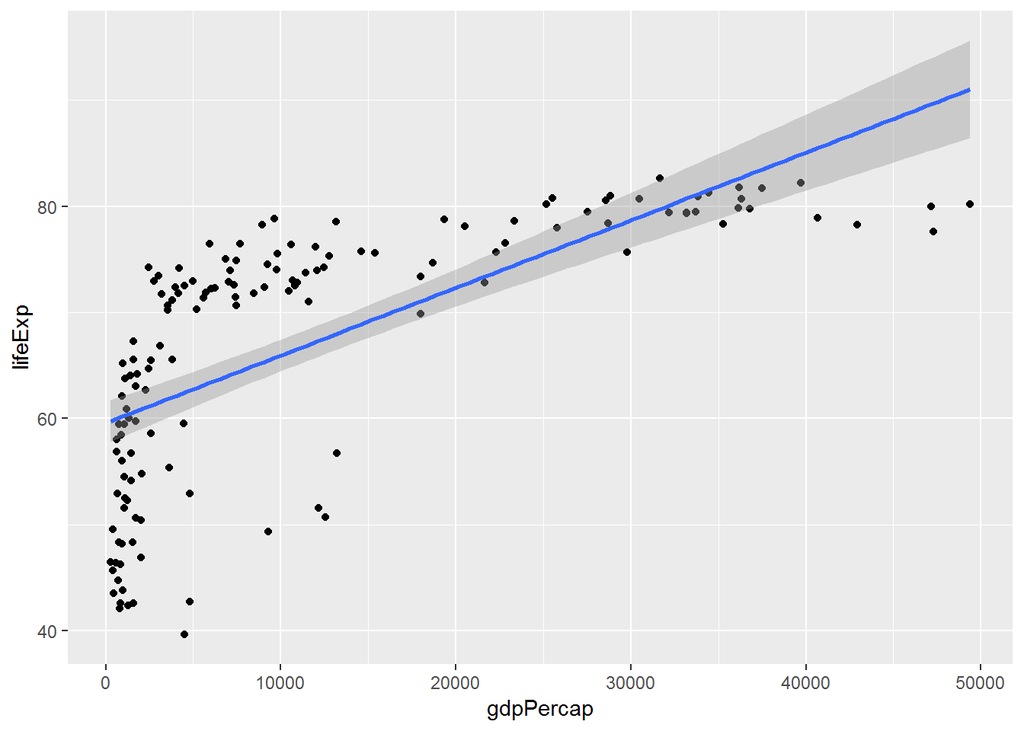

Or we can plot a correlation heatmap with the `GGally::ggcorr` function of the `GGally` ggplot extension package.

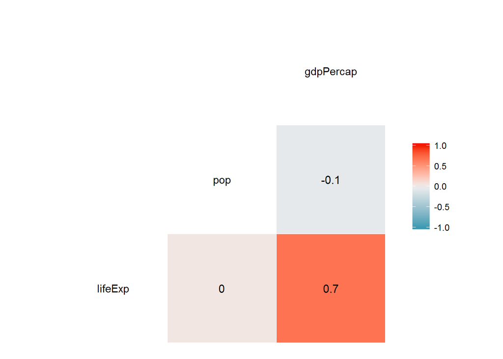

```r
ggcorr(gapminder_cs[, 4:6], label = TRUE)
```

## 1.4 Regression

Perhaps the simplest and most common analysis one would do is linear OLS regression. It allows to model a continuous variable as a linear combination (a sum) of one or several other continuous or binary variables so that in the end we would have a rough idea about how much our response variable would change if our explanatory variable would change by a certain amount. It is a simple, but rather flexible and powerful technique and the basic linear model can be extended to cover most of the analyses one could think of. The basic OLS is good also because it is relatively understandable. Its basic principle is minimising the sum of squared differences between the actual and the predicted values.

OLS is suitable if one has a continuous response variable, which is more or less normally distributed, continuous or binary explanatory variables and a reasonable amount of cases that are independent of each other. Rules of thumb with regard to the latter differ, but it would probably not be a good idea to run a regression with less than 20 cases, especially with many explanatory variables, and one should be OK if there are more than a 100 cases and not a very large amount of predictors. The more we want out of the data, i.e. the more coefficients and relationships we are looking at, the more information (cases) we would need in order to have stable and valid estimates about the associations we are interested in.

Out of the example data that we have had, let’s try to model the life expectancy in certain countries from the `gapminder` dataset as a function of the GDP per capita, population and spatial features (continent).

```r
reg1 <- lm(lifeExp ~ gdpPercap + pop + continent, data = gapminder_cs)

summary(reg1)
```

```
#>
#> Call:
#> lm(formula = lifeExp ~ gdpPercap + pop + continent, data = gapminder_cs)
#>
#> Residuals:
#>      Min       1Q   Median       3Q      Max
#> -22.8199  -2.8905   0.1574   2.9046  20.0585
#>
#> Coefficients:
#>                           Estimate       Std. Error t value
#> (Intercept)       53.7141900516204  0.9355709763972  57.413
#> gdpPercap          0.0003479123814  0.0000571704015   6.086
#> pop                0.0000000009586  0.0000000039259   0.244
#> continentAmericas 16.0313726693021  1.6713252557392   9.592
#> continentAsia     12.5640427449841  1.6209815371922   7.751
#> continentEurope   15.1989177617593  1.9662500363509   7.730
#> continentOceania  16.6222095573924  4.9925674316223   3.329
#>                               Pr(>|t|)
#> (Intercept)       < 0.0000000000000002 ***
#> gdpPercap             0.00000001127738 ***
#> pop                            0.80747
#> continentAmericas < 0.0000000000000002 ***
#> continentAsia         0.00000000000197 ***
#> continentEurope       0.00000000000220 ***
#> continentOceania               0.00112 **
#> ---
#> Signif. codes:  0 '***' 0.001 '**' 0.01 '*' 0.05 '.' 0.1 ' ' 1
#>
#> Residual standard error: 6.597 on 135 degrees of freedom
#> Multiple R-squared:  0.7141, Adjusted R-squared:  0.7014
#> F-statistic:  56.2 on 6 and 135 DF,  p-value: < 0.00000000000000022
```

The first thing we should always look at is model fit. This is shown us by the two values of R-squared at the bottom of the output. Out of these two, we should always look at adjusted R-squared, because this also takes into account the number of variables we have in the model and the number of cases that we have at our disposal. Any variable, even if there is no association at all, that is included in a model increases model fit a bit just by chance and we should account for that somehow.

Here we can see that the model fits rather well, the included independent variables help us account for 70% of the variance in a country’s average population life expectancy. With such a well fitting model, we can safely move on to interpreting the coefficients. They tell us that a 1 dollar per capita increase in the GDP per capita is associated with a 0.00035 increase in life expectancy (this should make us think a bit about the nature of the relationship and its possible limits).

We can also see that the effect size of the contient variable dwarfs the gdpPercap. This should not be a big surprise, as we cannot really claim to have a fully specified model so the continent variable is likely capturing a lot of other effects.

As in other cases, it might sometimes be better also here to present your results visually. For regressions (and linear models in general) this is made easy with the `effects` package, which can be used to isolate and plot the effect of a single variable together with its confidence intervals. The function `effect()` calculates the effect and takes the name of the variable and the model object as input and the generic `plot()` function can be used to plot the effect. Let’s see how this looks like for the model we just fitted.

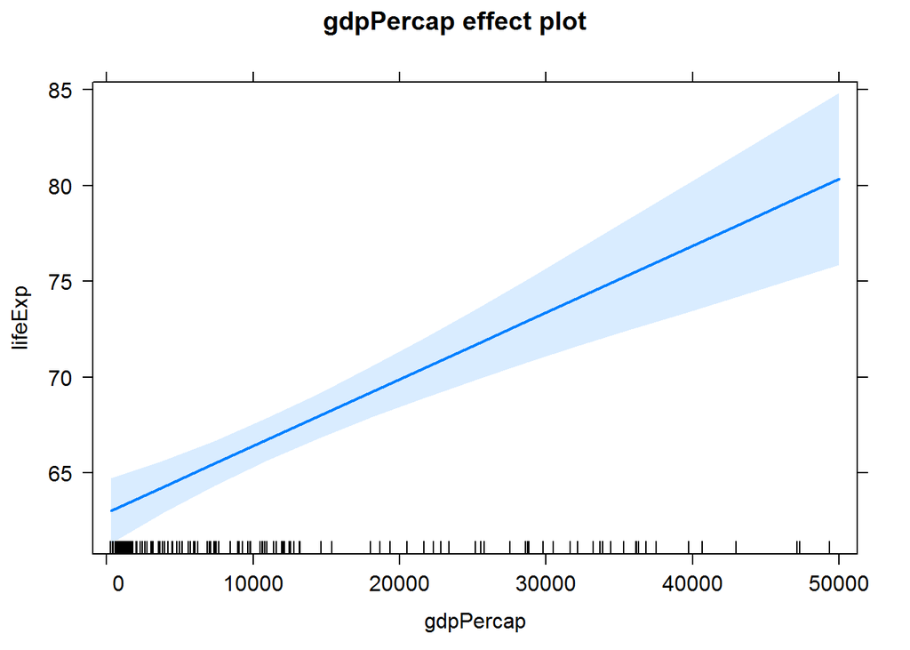

```r
plot(effect("gdpPercap", reg1))
```

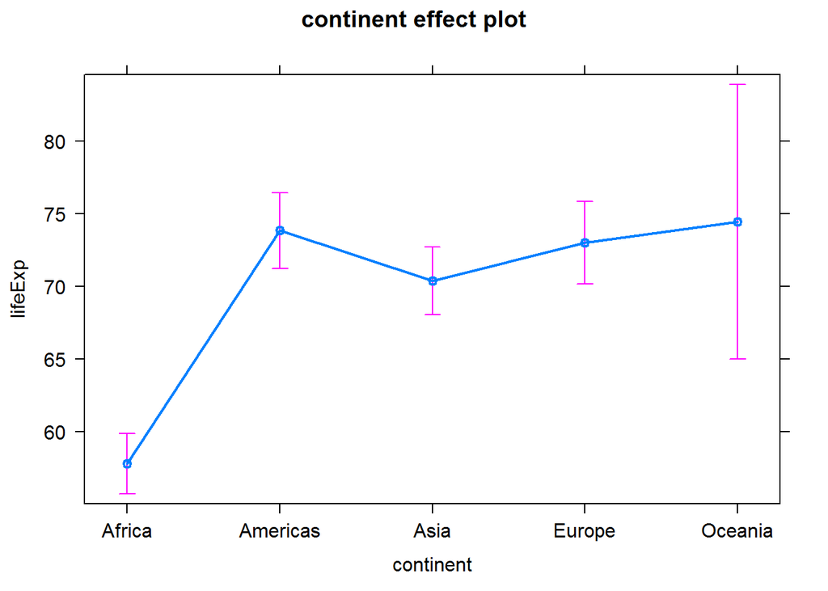

```r
plot(effect("continent", reg1))
```

Since we know that GDP per capita data is skewed, we can experiment with the log transformed variable. We can do the transformation within the formula, no need to modify the data directly.

```r
reg2 <- lm(lifeExp ~ log(gdpPercap) + pop + continent, data = gapminder_cs)

summary(reg2)
```

```
#>
#> Call:
#> lm(formula = lifeExp ~ log(gdpPercap) + pop + continent, data = gapminder_cs)
#>
#> Residuals:
#>      Min       1Q   Median       3Q      Max
#> -19.4851  -2.3248  -0.0113   2.4129  14.8837
#>
#> Coefficients:
#>                           Estimate       Std. Error t value
#> (Intercept)       20.0498777707212  4.0609442980348   4.937
#> log(gdpPercap)     4.6402800649035  0.5304747318434   8.747
#> pop                0.0000000009243  0.0000000035345   0.261
#> continentAmericas 11.6629039640544  1.6645718146073   7.007
#> continentAsia     10.0122605443785  1.5318564142268   6.536
#> continentEurope   11.2429299938201  1.9025523688813   5.909
#> continentOceania  12.9078376412485  4.5374002372938   2.845
#>                              Pr(>|t|)
#> (Intercept)       0.00000229893636301 ***
#> log(gdpPercap)    0.00000000000000773 ***
#> pop                           0.79411
#> continentAmericas 0.00000000010528675 ***
#> continentAsia     0.00000000119233160 ***
#> continentEurope   0.00000002654074081 ***
#> continentOceania              0.00514 **
#> ---
#> Signif. codes:  0 '***' 0.001 '**' 0.01 '*' 0.05 '.' 0.1 ' ' 1
#>
#> Residual standard error: 5.95 on 135 degrees of freedom
#> Multiple R-squared:  0.7675, Adjusted R-squared:  0.7572
#> F-statistic: 74.27 on 6 and 135 DF,  p-value: < 0.00000000000000022
```

For further diagnostic plots, we can use the `ggfortify` extension of ggplot. This allows us to quickly plot key diagnostics and if needed use the `ggplot` syntax to change elements of the plots. The `ggfortify::autoplot()` figures everything out for us. You can select which plots you need with the `which = 1:6` option.

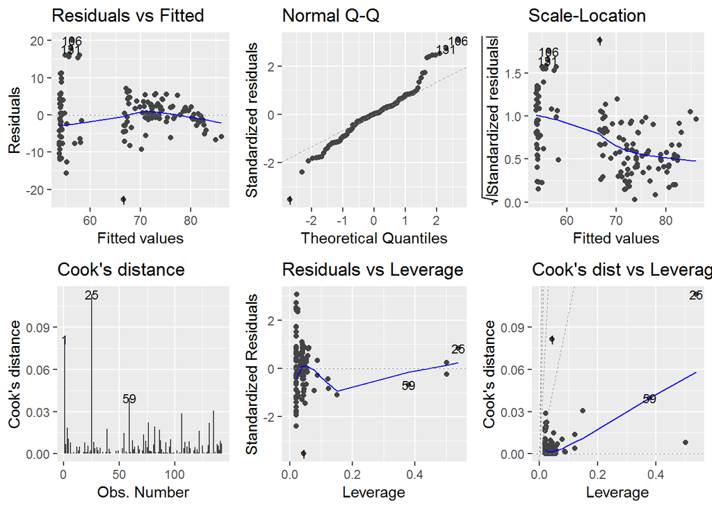

```r
autoplot(reg1, which = 1:6, ncol = 3, label.size = 3)
```

## 1.5 Model objects and the `broom` package

Let’s dig into our regression objects. We’ll stick to the `reg1` object for now. A quick way to look into our object is the `str()` function.

```r
str(reg1)
```

```
#> List of 13
#>  $ coefficients : Named num [1:7] 53.71419005162 0.000347912381 0.000000000959 16.031372669302 12.564042744984 ...
#>   ..- attr(*, "names")= chr [1:7] "(Intercept)" "gdpPercap" "pop" "continentAmericas" ...
#>  $ residuals    : Named num [1:142] -22.82 5.44 16.39 -12.66 1.09 ...
#>   ..- attr(*, "names")= chr [1:142] "1" "2" "3" "4" ...
#>  $ effects      : Named num [1:142] -798.5 97.3 12.3 39.1 29.5 ...
#>   ..- attr(*, "names")= chr [1:142] "(Intercept)" "gdpPercap" "pop" "continentAmericas" ...
#>  $ rank         : int 7
#>  $ fitted.values: Named num [1:142] 66.6 71 55.9 55.4 74.2 ...
#>   ..- attr(*, "names")= chr [1:142] "1" "2" "3" "4" ...
#>  $ assign       : int [1:7] 0 1 2 3 3 3 3
#>  $ qr           :List of 5
#>   ..$ qr   : num [1:142, 1:7] -11.9164 0.0839 0.0839 0.0839 0.0839 ...
#>   .. ..- attr(*, "dimnames")=List of 2
#>   .. .. ..$ : chr [1:142] "1" "2" "3" "4" ...
#>   .. .. ..$ : chr [1:7] "(Intercept)" "gdpPercap" "pop" "continentAmericas" ...
#>   .. ..- attr(*, "assign")= int [1:7] 0 1 2 3 3 3 3
#>   .. ..- attr(*, "contrasts")=List of 1
#>   .. .. ..$ continent: chr "contr.treatment"
#>   ..$ qraux: num [1:7] 1.08 1.03 1.01 1.04 1.03 ...
#>   ..$ pivot: int [1:7] 1 2 3 4 5 6 7
#>   ..$ tol  : num 0.0000001
#>   ..$ rank : int 7
#>   ..- attr(*, "class")= chr "qr"
#>  $ df.residual  : int 135
#>  $ contrasts    :List of 1
#>   ..$ continent: chr "contr.treatment"
#>  $ xlevels      :List of 1
#>   ..$ continent: chr [1:5] "Africa" "Americas" "Asia" "Europe" ...
#>  $ call         : language lm(formula = lifeExp ~ gdpPercap + pop + continent, data = gapminder_cs)
#>  $ terms        :Classes 'terms', 'formula'  language lifeExp ~ gdpPercap + pop + continent
#>   .. ..- attr(*, "variables")= language list(lifeExp, gdpPercap, pop, continent)
#>   .. ..- attr(*, "factors")= int [1:4, 1:3] 0 1 0 0 0 0 1 0 0 0 ...
#>   .. .. ..- attr(*, "dimnames")=List of 2
#>   .. .. .. ..$ : chr [1:4] "lifeExp" "gdpPercap" "pop" "continent"
#>   .. .. .. ..$ : chr [1:3] "gdpPercap" "pop" "continent"
#>   .. ..- attr(*, "term.labels")= chr [1:3] "gdpPercap" "pop" "continent"
#>   .. ..- attr(*, "order")= int [1:3] 1 1 1
#>   .. ..- attr(*, "intercept")= int 1
#>   .. ..- attr(*, "response")= int 1
```

[output cut: 9 more lines]

```
#>   ..- attr(*, "terms")=Classes 'terms', 'formula'  language lifeExp ~ gdpPercap + pop + continent
#>   .. .. ..- attr(*, "variables")= language list(lifeExp, gdpPercap, pop, continent)
#>   .. .. ..- attr(*, "factors")= int [1:4, 1:3] 0 1 0 0 0 0 1 0 0 0 ...
#>   .. .. .. ..- attr(*, "dimnames")=List of 2
#>   .. .. .. .. ..$ : chr [1:4] "lifeExp" "gdpPercap" "pop" "continent"
#>   .. .. .. .. ..$ : chr [1:3] "gdpPercap" "pop" "continent"
#>   .. .. ..- attr(*, "term.labels")= chr [1:3] "gdpPercap" "pop" "continent"
#>   .. .. ..- attr(*, "order")= int [1:3] 1 1 1
#>   .. .. ..- attr(*, "intercept")= int 1
#>   .. .. ..- attr(*, "response")= int 1
#>   .. .. ..- attr(*, ".Environment")=<environment: R_GlobalEnv>
#>   .. .. ..- attr(*, "predvars")= language list(lifeExp, gdpPercap, pop, continent)
#>   .. .. ..- attr(*, "dataClasses")= Named chr [1:4] "numeric" "numeric" "numeric" "factor"
#>   .. .. .. ..- attr(*, "names")= chr [1:4] "lifeExp" "gdpPercap" "pop" "continent"
#>  - attr(*, "class")= chr "lm"
```

Well, this does look cluttered. Using `names()` helps.

```r
names(reg1)
```

```
#>  [1] "coefficients"  "residuals"     "effects"       "rank"
#>  [5] "fitted.values" "assign"        "qr"            "df.residual"
#>  [9] "contrasts"     "xlevels"       "call"          "terms"
#> [13] "model"
```

As our object is basically a list, we can dig into it, with the usual methods.

```r
reg1$coefficients
```

```
#>         (Intercept)           gdpPercap                 pop
#> 53.7141900516203989  0.0003479123813783  0.0000000009586008
#>   continentAmericas       continentAsia     continentEurope
#> 16.0313726693021081 12.5640427449841319 15.1989177617592635
#>    continentOceania
#> 16.6222095573923809
```

There are other ways to access this information, with built in functions.

```r
coef(reg1)
```

```
#>         (Intercept)           gdpPercap                 pop
#> 53.7141900516203989  0.0003479123813783  0.0000000009586008
#>   continentAmericas       continentAsia     continentEurope
#> 16.0313726693021081 12.5640427449841319 15.1989177617592635
#>    continentOceania
#> 16.6222095573923809
```

It is also useful to keep in mind that if you call the `summary()` function on a model object, then this creates a new kind of an object, also with its own internal structure, that might have useful information for us.

```r
summary_reg1 <- summary(reg1)

str(summary_reg1)
```

```
#> List of 11
#>  $ call         : language lm(formula = lifeExp ~ gdpPercap + pop + continent, data = gapminder_cs)
#>  $ terms        :Classes 'terms', 'formula'  language lifeExp ~ gdpPercap + pop + continent
#>   .. ..- attr(*, "variables")= language list(lifeExp, gdpPercap, pop, continent)
#>   .. ..- attr(*, "factors")= int [1:4, 1:3] 0 1 0 0 0 0 1 0 0 0 ...
#>   .. .. ..- attr(*, "dimnames")=List of 2
#>   .. .. .. ..$ : chr [1:4] "lifeExp" "gdpPercap" "pop" "continent"
#>   .. .. .. ..$ : chr [1:3] "gdpPercap" "pop" "continent"
#>   .. ..- attr(*, "term.labels")= chr [1:3] "gdpPercap" "pop" "continent"
#>   .. ..- attr(*, "order")= int [1:3] 1 1 1
#>   .. ..- attr(*, "intercept")= int 1
#>   .. ..- attr(*, "response")= int 1
#>   .. ..- attr(*, ".Environment")=<environment: R_GlobalEnv>
#>   .. ..- attr(*, "predvars")= language list(lifeExp, gdpPercap, pop, continent)
#>   .. ..- attr(*, "dataClasses")= Named chr [1:4] "numeric" "numeric" "numeric" "factor"
#>   .. .. ..- attr(*, "names")= chr [1:4] "lifeExp" "gdpPercap" "pop" "continent"
#>  $ residuals    : Named num [1:142] -22.82 5.44 16.39 -12.66 1.09 ...
#>   ..- attr(*, "names")= chr [1:142] "1" "2" "3" "4" ...
#>  $ coefficients : num [1:7, 1:4] 53.71419005162 0.000347912381 0.000000000959 16.031372669302 12.564042744984 ...
#>   ..- attr(*, "dimnames")=List of 2
#>   .. ..$ : chr [1:7] "(Intercept)" "gdpPercap" "pop" "continentAmericas" ...
#>   .. ..$ : chr [1:4] "Estimate" "Std. Error" "t value" "Pr(>|t|)"
#>  $ aliased      : Named logi [1:7] FALSE FALSE FALSE FALSE FALSE FALSE ...
#>   ..- attr(*, "names")= chr [1:7] "(Intercept)" "gdpPercap" "pop" "continentAmericas" ...
#>  $ sigma        : num 6.6
#>  $ df           : int [1:3] 7 135 7
#>  $ r.squared    : num 0.714
#>  $ adj.r.squared: num 0.701
#>  $ fstatistic   : Named num [1:3] 56.2 6 135
#>   ..- attr(*, "names")= chr [1:3] "value" "numdf" "dendf"
#>  $ cov.unscaled : num [1:7, 1:7] 0.02011186815794 -0.00000024029387 -0.00000000000777 -0.01718868145553 -0.01621759549712 ...
#>   ..- attr(*, "dimnames")=List of 2
#>   .. ..$ : chr [1:7] "(Intercept)" "gdpPercap" "pop" "continentAmericas" ...
#>   .. ..$ : chr [1:7] "(Intercept)" "gdpPercap" "pop" "continentAmericas" ...
#>  - attr(*, "class")= chr "summary.lm"
```

### 1.5.1 Using `broom`

To make the somewhat messy regression output more “tidy”, we’ll use the `broom` package’s `broom::tidy()` function. It creates a data frame from our regression object with the estimate, se, f statistics and p.value columns, and each IV as row.

```r
reg1_tidy <- tidy(reg1, conf.int = TRUE)

reg1_tidy
```

```
#> # A tibble: 7 x 7
#>   term           estimate   std.error statistic  p.value conf.low conf.high
#>   <chr>             <dbl>       <dbl>     <dbl>    <dbl>    <dbl>     <dbl>
#> 1 (Intercept)    5.37e+ 1     9.36e-1    57.4   9.97e-97  5.19e+1   5.56e+1
#> 2 gdpPercap      3.48e- 4     5.72e-5     6.09  1.13e- 8  2.35e-4   4.61e-4
#> 3 pop            9.59e-10     3.93e-9     0.244 8.07e- 1 -6.81e-9   8.72e-9
#> 4 continentAmer~ 1.60e+ 1     1.67e+0     9.59  6.20e-17  1.27e+1   1.93e+1
#> 5 continentAsia  1.26e+ 1     1.62e+0     7.75  1.97e-12  9.36e+0   1.58e+1
#> 6 continentEuro~ 1.52e+ 1     1.97e+0     7.73  2.20e-12  1.13e+1   1.91e+1
#> 7 continentOcea~ 1.66e+ 1     4.99e+0     3.33  1.12e- 3  6.75e+0   2.65e+1
```

To get more information into our data frame, use the `broom::augment()` function, will add the fitted values, residuals as well.

```r
reg1_aug <- augment(reg1)

head(reg1_aug, 10)
```

```
#> # A tibble: 10 x 11
#>    lifeExp gdpPercap    pop continent .fitted .se.fit .resid   .hat .sigma
#>      <dbl>     <dbl>  <int> <fct>       <dbl>   <dbl>  <dbl>  <dbl>  <dbl>
#>  1    43.8      975. 3.19e7 Asia         66.6   1.38  -22.8  0.0436   6.31
#>  2    76.4     5937. 3.60e6 Europe       71.0   1.63    5.44 0.0612   6.60
#>  3    72.3     6223. 3.33e7 Africa       55.9   0.935  16.4  0.0201   6.47
#>  4    42.7     4797. 1.24e7 Africa       55.4   0.920 -12.7  0.0195   6.53
#>  5    75.3    12779. 4.03e7 Americas     74.2   1.32    1.09 0.0403   6.62
#>  6    81.2    34435. 2.04e7 Oceania      82.3   4.67   -1.10 0.502    6.62
#>  7    79.8    36126. 8.20e6 Europe       81.5   1.36   -1.66 0.0425   6.62
#>  8    75.6    29796. 7.09e5 Asia         76.6   1.56   -1.01 0.0557   6.62
#>  9    64.1     1391. 1.50e8 Asia         66.9   1.31   -2.84 0.0396   6.62
#> 10    79.4    33693. 1.04e7 Europe       80.6   1.30   -1.20 0.0389   6.62
#> # ... with 2 more variables: .cooksd <dbl>, .std.resid <dbl>
```

If we need the model diagnostics, use the `broom::glance()` function.

```r
glance(reg1)
```

```
#> # A tibble: 1 x 11
#>   r.squared adj.r.squared sigma statistic  p.value    df logLik   AIC   BIC
#>       <dbl>         <dbl> <dbl>     <dbl>    <dbl> <int>  <dbl> <dbl> <dbl>
#> 1     0.714         0.701  6.60      56.2 2.41e-34     7  -466.  948.  971.
#> # ... with 2 more variables: deviance <dbl>, df.residual <int>
```

As we now have our regression output in a tidy format we can turn to `ggplot2` to exploit its tools and visualize. First, we can plot the fitted values and residuals to check for heteroskedasticity.

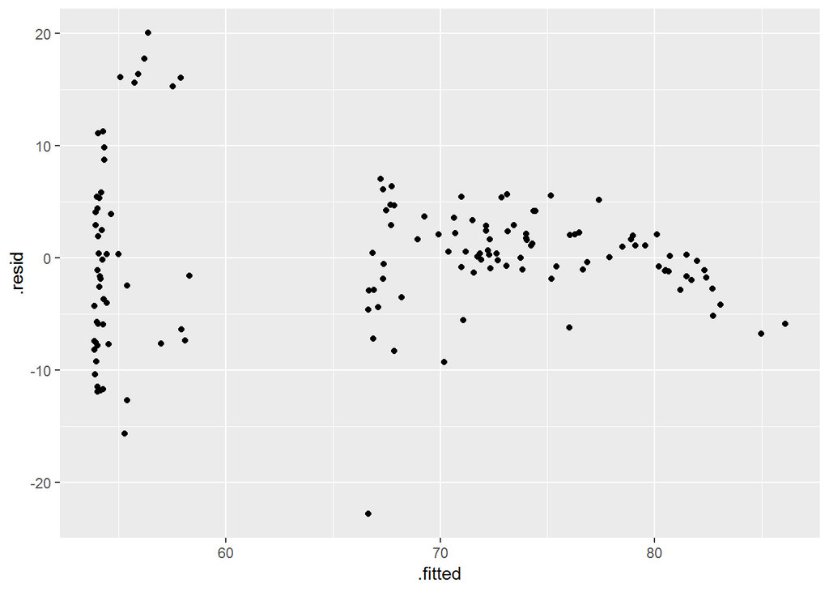

```r
ggplot(data = reg1_aug,
       mapping = aes(x = .fitted,
                     y = .resid)) +
    geom_point()
```

Or create a coefficent plot. (Don’t forget to add the `conf.int` parameter as `TRUE` to the `tidy()` call.) For `geom_errorbar` the `width` argument controls the size of the whiskers, for the `geom_errorbarh`, it is the `height =`

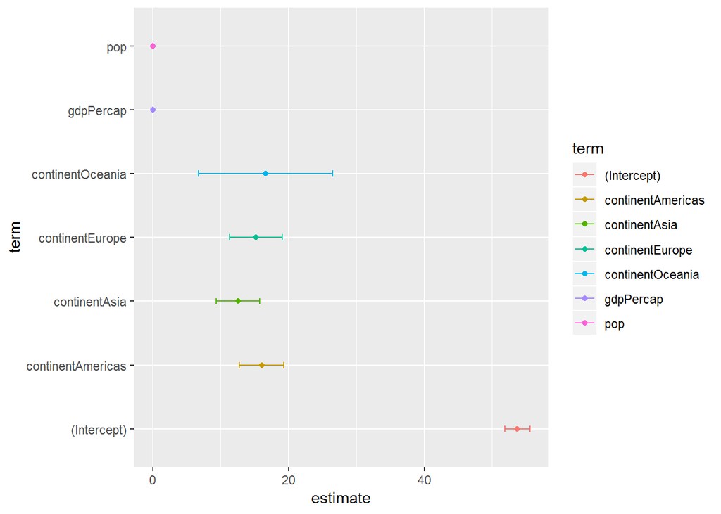

```r
ggplot(reg1_tidy, aes(term, estimate, color = term)) +
    geom_point() +
    geom_errorbar(aes(ymin = conf.low, ymax = conf.high, width = 0.1)) +
    coord_flip()
```

## 1.6 Working with survey data (OPTIONAL)

For this the `survey` package offers an excellent set of tools. This section briefly introduced the basics and provides an introduction for further use.

Data from Euorpean Values Study 2008 (ZA4800: EVS 2008: Integrated Dataset). Variable descriptions are available here: https://zacat.gesis.org/webview/index.jsp?object=http://zacat.gesis.org/obj/fCatalog/Catalog5

```r
evs_aggregated <- read_dta("data/EVS.dta")
```

```r
# checking the type of our selected variables
vars_evs <- c("v214", "v302", "v336_r", "v200", "age")

sapply(evs_aggregated[vars_evs], typeof)
```

```
#>     v214     v302   v336_r     v200      age
#> "double" "double" "double" "double" "double"
```

Just quickly recode them.

```r
evs_recode <- evs_aggregated %>%
    mutate(trust_eu = factor(v214), sex = factor(v302), educ = factor(v336_r), op_soc = factor(v200))
```

The workflow with the `survey` package is usually the following: - create a survey object specifying the design of the survey (clustering, weights, data) - explore - model

Note: we use *formulas* in the functions, similar to what we used for specifying the regression formula. The `ids = 0` means we have no clusters in the survey.

```r
evs_survey <- svydesign(ids = ~0, data = evs_recode, weights = ~weight_s)
```

After this is done we can carry out the basic summary statistics with survey weights. The applicable functions are `svymean`, `svyvar`, `svytotal`

```r
# age of respondent
svymean(~age, evs_survey, deff = TRUE, na.rm = TRUE)
```

```
#>          mean        SE  DEff
#> age 45.681409  0.075226 78286
```

```r
# opinion on society:
# 1 the entire way our society is organized must be radically changed by revolutionary action
# 2 our society must be gradually changed by reforms
# 3 our present society must be valiantly defended against all changes
svymean(~op_soc, evs_survey, deff = TRUE, na.rm = TRUE)
```

```
#>              mean        SE   DEff
#> op_soc1 0.1165090 0.0013814 437.21
#> op_soc2 0.7749351 0.0018043 440.20
#> op_soc3 0.1085559 0.0013504 444.43
```

Create crosstabs using the `svyby()` function in combination with the `ftable()`. V214 (Q63J): how much confidence in: european union. by v302 (Q86) Sex

```r
tab <- svyby(~trust_eu, ~sex, evs_survey, svymean, na.rm = TRUE)

round(ftable(tab), 2)
```

```
#>              trust_eu1 trust_eu2 trust_eu3 trust_eu4
#> sex
#> 1   svymean       0.11      0.40      0.32      0.17
#>     SE            0.00      0.00      0.00      0.00
#> 2   svymean       0.10      0.41      0.34      0.15
#>     SE            0.00      0.00      0.00      0.00
```

Test associaton (is EU opinion different across genders?)

```r
svychisq(~trust_eu + sex, evs_survey)
```

```
#>
#>  Pearson's X^2: Rao & Scott adjustment
#>
#> data:  svychisq(~trust_eu + sex, evs_survey)
#> F = 13.633, ndf = 2.9995, ddf = 198810.0000, p-value =
#> 0.000000006904
```

We can also carry out regression analysis, applying generalized linear models, estimated by `svyglm`.

```r
svreg <- svyglm(v353M_ppp ~ age + educ, evs_survey)
summary(svreg)
```

```
#>
#> Call:
#> svyglm(formula = v353M_ppp ~ age + educ, design = evs_survey)
#>
#> Survey design:
#> svydesign(ids = ~0, data = evs_recode, weights = ~weight_s)
#>
#> Coefficients:
#>               Estimate Std. Error t value            Pr(>|t|)
#> (Intercept)  1.1664349  0.0212343   54.93 <0.0000000000000002 ***
#> age         -0.0039443  0.0003212  -12.28 <0.0000000000000002 ***
#> educ2        0.1607409  0.0127918   12.57 <0.0000000000000002 ***
#> educ3        0.8026608  0.0186739   42.98 <0.0000000000000002 ***
#> ---
#> Signif. codes:  0 '***' 0.001 '**' 0.01 '*' 0.05 '.' 0.1 ' ' 1
#>
#> (Dispersion parameter for gaussian family taken to be 1.601609)
#>
#> Number of Fisher Scoring iterations: 2
```

## 1.7 Panel regression with `plm` (OPTIONAL)

The `plm` package is designed to estimate panel regressions. You can use it for balanced and unbalanced panels as well for estimating pooled OLS, fixed effects, random effects and dynamic panel models. If you are interested it has a great documentation on all of its features: https://cran.r-project.org/web/packages/plm/vignettes/

```r
gapminder <- gapminder
panel_gapminder <- pdata.frame(gapminder, index = c("country", "year"))
```

Pooled OLS, by specifying `model = "pooling"`.

```r
pols <- plm(lifeExp ~ continent + gdpPercap, data = panel_gapminder, model = "pooling")

summary(pols)
```

```
#> Pooling Model
#>
#> Call:
#> plm(formula = lifeExp ~ continent + gdpPercap, data = panel_gapminder,
#>     model = "pooling")
#>
#> Balanced Panel: n = 142, T = 12, N = 1704
#>
#> Residuals:
#>      Min.   1st Qu.    Median   3rd Qu.      Max.
#> -49.24076  -4.47905   0.34664   5.10453  25.13821
#>
#> Coefficients:
#>                       Estimate   Std. Error t-value              Pr(>|t|)
#> (Intercept)       47.888516179  0.339805317 140.929 < 0.00000000000000022
#> continentAmericas 13.592721871  0.600785625  22.625 < 0.00000000000000022
#> continentAsia      8.657793477  0.555485873  15.586 < 0.00000000000000022
#> continentEurope   17.572340967  0.625742962  28.082 < 0.00000000000000022
#> continentOceania  18.146041015  1.787426208  10.152 < 0.00000000000000022
#> gdpPercap          0.000445270  0.000023498  18.949 < 0.00000000000000022
#>
#> (Intercept)       ***
#> continentAmericas ***
#> continentAsia     ***
#> continentEurope   ***
#> continentOceania  ***
#> gdpPercap         ***
#> ---
#> Signif. codes:  0 '***' 0.001 '**' 0.01 '*' 0.05 '.' 0.1 ' ' 1
#>
#> Total Sum of Squares:    284150
#> Residual Sum of Squares: 119530
#> R-Squared:      0.57934
#> Adj. R-Squared: 0.57811
#> F-statistic: 467.712 on 5 and 1698 DF, p-value: < 0.000000000000000222
```

Fixed effects with `model = "within"`. Notice that we loose contitent, as they are differenced out during the estimation as they are time invarient.

```r
fe <- plm(lifeExp ~ continent + gdpPercap, data = panel_gapminder, model = "within")

summary(fe)
```

```
#> Oneway (individual) effect Within Model
#>
#> Call:
#> plm(formula = lifeExp ~ continent + gdpPercap, data = panel_gapminder,
#>     model = "within")
#>
#> Balanced Panel: n = 142, T = 12, N = 1704
#>
#> Residuals:
#>      Min.   1st Qu.    Median   3rd Qu.      Max.
#> -31.69748  -3.42408   0.32109   3.68425  21.10597
#>
#> Coefficients:
#>              Estimate  Std. Error t-value              Pr(>|t|)
#> gdpPercap 0.000426025 0.000031141  13.681 < 0.00000000000000022 ***
#> ---
#> Signif. codes:  0 '***' 0.001 '**' 0.01 '*' 0.05 '.' 0.1 ' ' 1
#>
#> Total Sum of Squares:    73973
#> Residual Sum of Squares: 66053
#> R-Squared:      0.10706
#> Adj. R-Squared: 0.025831
#> F-statistic: 187.157 on 1 and 1561 DF, p-value: < 0.000000000000000222
```

Random effects

```r
re <- plm(lifeExp ~ continent + gdpPercap, data = panel_gapminder, model = "random")

summary(re)
```

```
#> Oneway (individual) effect Random Effect Model
#>    (Swamy-Arora's transformation)
#>
#> Call:
#> plm(formula = lifeExp ~ continent + gdpPercap, data = panel_gapminder,
#>     model = "random")
#>
#> Balanced Panel: n = 142, T = 12, N = 1704
#>
#> Effects:
#>                  var std.dev share
#> idiosyncratic 42.315   6.505 0.591
#> individual    29.226   5.406 0.409
#> theta: 0.6719
#>
#> Residuals:
#>      Min.   1st Qu.    Median   3rd Qu.      Max.
#> -37.12979  -3.56735   0.44311   4.06314  16.66526
#>
#> Coefficients:
#>                       Estimate   Std. Error z-value              Pr(>|z|)
#> (Intercept)       47.919731241  0.795859043 60.2113 < 0.00000000000000022
#> continentAmericas 13.663046940  1.399485392  9.7629 < 0.00000000000000022
#> continentAsia      8.739018575  1.283619019  6.8081     0.000000000009889
#> continentEurope   17.747012919  1.357103052 13.0771 < 0.00000000000000022
#> continentOceania  18.379793920  4.148970526  4.4300     0.000009424841446
#> gdpPercap          0.000431041  0.000028339 15.2101 < 0.00000000000000022
#>
#> (Intercept)       ***
#> continentAmericas ***
#> continentAsia     ***
#> continentEurope   ***
#> continentOceania  ***
#> gdpPercap         ***
#> ---
#> Signif. codes:  0 '***' 0.001 '**' 0.01 '*' 0.05 '.' 0.1 ' ' 1
#>
#> Total Sum of Squares:    96601
#> Residual Sum of Squares: 71814
#> R-Squared:      0.25659
#> Adj. R-Squared: 0.2544
#> Chisq: 586.069 on 5 DF, p-value: < 0.000000000000000222
```

Which should we use? A general rule of thumb test is the Hausman test. If the p-value is below your significance level (e.g.:0.05), then you should use the fixed effects.

```r
phtest(fe, re)
```

```
#>
#>  Hausman Test
#>
#> data:  lifeExp ~ continent + gdpPercap
#> chisq = 0.15098, df = 1, p-value = 0.6976
#> alternative hypothesis: one model is inconsistent
```